# Projet ACP

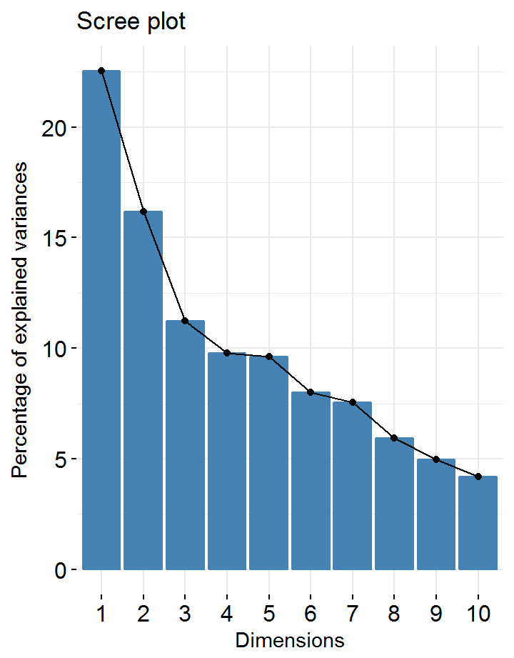

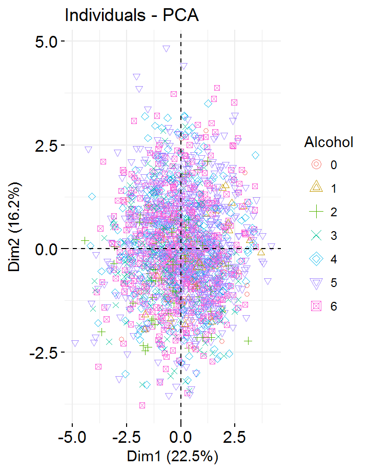

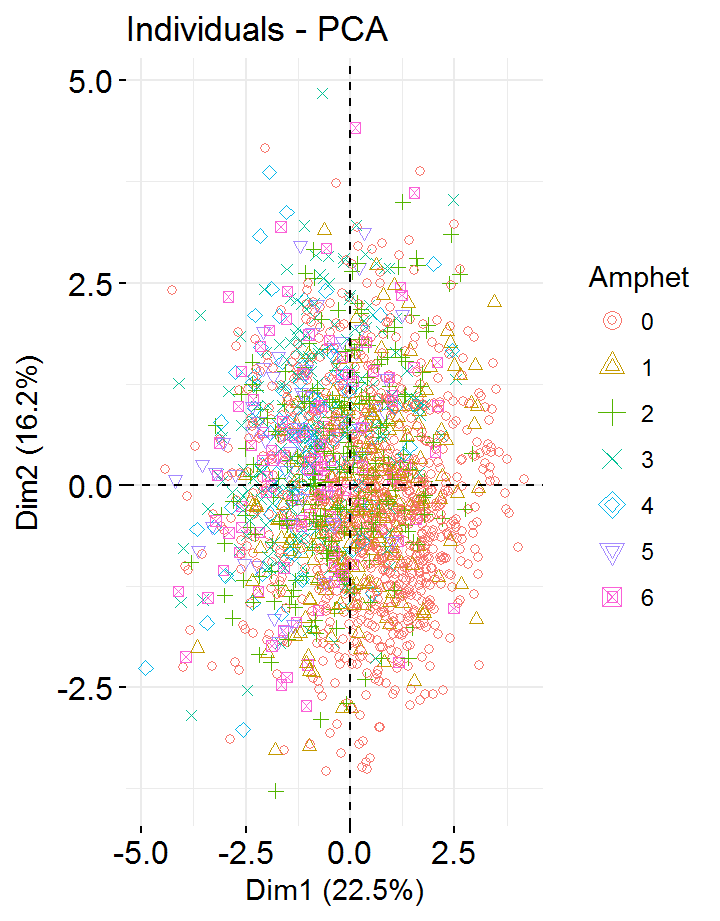

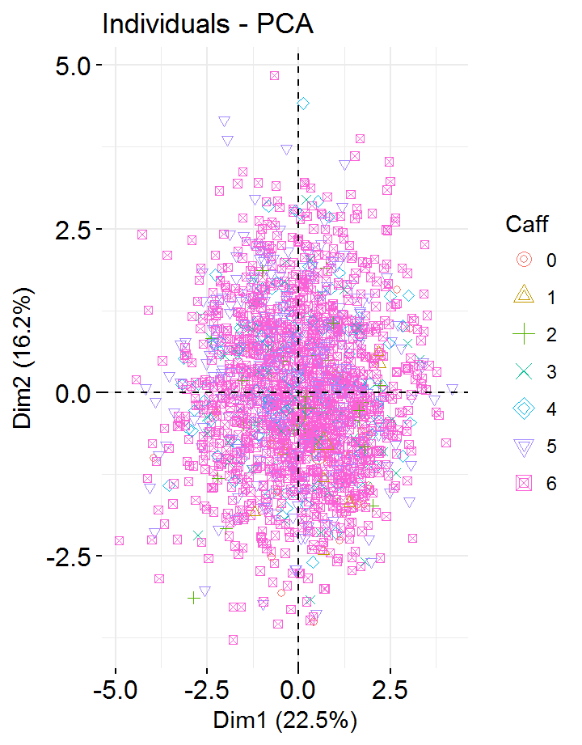

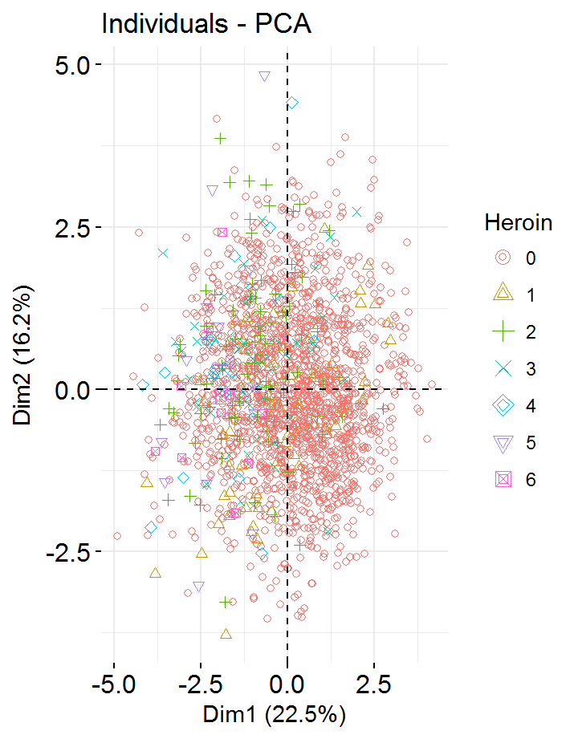

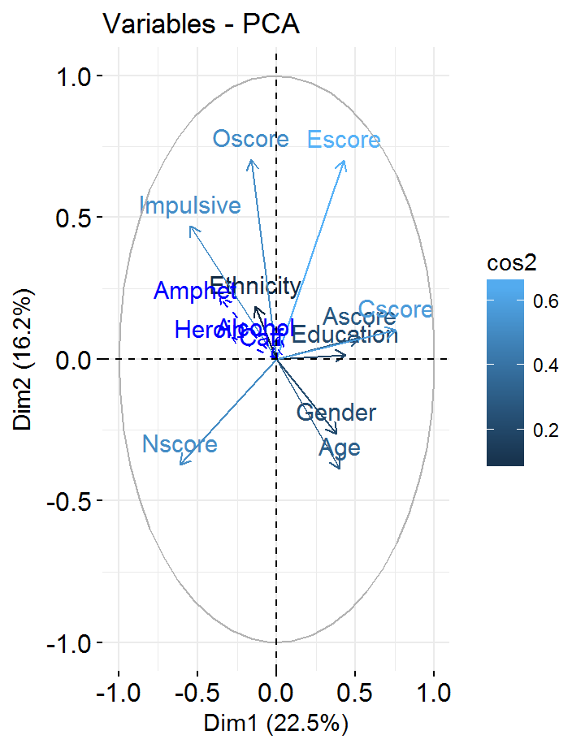

# Presentation des données

### Description

Nous avons travaillé sur la base “Drug consumption”. La table contient 1885 observations (qui sont 1885 individus interogés) et 32 variables sans aucune valeures manquantes. Ce qu’il faut savoir c’est que Toutes les variables sont initialement catégorielles et quantifiées, c’après quoi elles peuvent être considérées comme réelles. Les participants ont été interrogés sur leur utilisation de 18 drogues légales et illégales et pour chaque individu, on connait certaines mesures de personalité et aussi le niveau d’éducation, L’âge, le sexe, le pays de résidence et l’appartenance ethnique. Pour notree etude, nous nous sommes limités à 14 variables que sont : age, gender, education, ethnicity, Nscore, Escore, Oscore, Ascore, Cscore, Impulsive, Alcohol, amphet, caff, heroin. Notre objectif etant de determiner les facteursliés a la consomation des drogues etudiées, les 10 premieres variables constitueront nos variables actives tandisque les 4 autres qui determine la consomation des 4 differentes drogues seront nos variables suplementaires.

### Apercue des données brutes

```
   V1       V2       V3       V4       V5       V6       V7       V8
1   1  0.49788  0.48246 -0.05921  0.96082  0.12600  0.31287 -0.57545
2   2 -0.07854 -0.48246  1.98437  0.96082 -0.31685 -0.67825  1.93886
3   3  0.49788 -0.48246 -0.05921  0.96082 -0.31685 -0.46725  0.80523
4   4 -0.95197  0.48246  1.16365  0.96082 -0.31685 -0.14882 -0.80615
5   5  0.49788  0.48246  1.98437  0.96082 -0.31685  0.73545 -1.63340
6   6  2.59171  0.48246 -1.22751  0.24923 -0.31685 -0.67825 -0.30033
7   7  1.09449 -0.48246  1.16365 -0.57009 -0.31685 -0.46725 -1.09207
8   8  0.49788 -0.48246 -1.73790  0.96082 -0.31685 -1.32828  1.93886
9   9  0.49788  0.48246 -0.05921  0.24923 -0.31685  0.62967  2.57309
10 10  1.82213 -0.48246  1.16365  0.96082 -0.31685 -0.24649  0.00332
         V9      V10      V11      V12      V13 V14 V15 V16 V17 V18 V19
1  -0.58331 -0.91699 -0.00665 -0.21712 -1.18084 CL5 CL2 CL0 CL2 CL6 CL0
2   1.43533  0.76096 -0.14277 -0.71126 -0.21575 CL5 CL2 CL2 CL0 CL6 CL4
3  -0.84732 -1.62090 -1.01450 -1.37983  0.40148 CL6 CL0 CL0 CL0 CL6 CL3
4  -0.01928  0.59042  0.58489 -1.37983 -1.18084 CL4 CL0 CL0 CL3 CL5 CL2
5  -0.45174 -0.30172  1.30612 -0.21712 -0.21575 CL4 CL1 CL1 CL0 CL6 CL3
6  -1.55521  2.03972  1.63088 -1.37983 -1.54858 CL2 CL0 CL0 CL0 CL6 CL0
7  -0.45174 -0.30172  0.93949 -0.21712  0.07987 CL6 CL0 CL0 CL0 CL6 CL1
8  -0.84732 -0.30172  1.63088  0.19268 -0.52593 CL5 CL0 CL0 CL0 CL6 CL0
9  -0.97631  0.76096  1.13407 -1.37983 -1.54858 CL4 CL0 CL0 CL0 CL6 CL0
10 -1.42424  0.59042  0.12331 -1.37983 -0.84637 CL6 CL1 CL0 CL1 CL6 CL1
   V20 V21 V22 V23 V24 V25 V26 V27 V28 V29 V30 V31 V32
1  CL5 CL0 CL0 CL0 CL0 CL0 CL0 CL0 CL0 CL0 CL2 CL0 CL0
2  CL6 CL3 CL0 CL4 CL0 CL2 CL0 CL2 CL3 CL0 CL4 CL0 CL0
3  CL4 CL0 CL0 CL0 CL0 CL0 CL0 CL0 CL0 CL1 CL0 CL0 CL0
4  CL4 CL2 CL0 CL0 CL0 CL2 CL0 CL0 CL0 CL0 CL2 CL0 CL0
5  CL6 CL0 CL0 CL1 CL0 CL0 CL1 CL0 CL0 CL2 CL2 CL0 CL0
6  CL4 CL0 CL0 CL0 CL0 CL0 CL0 CL0 CL0 CL0 CL6 CL0 CL0
7  CL5 CL0 CL0 CL0 CL0 CL0 CL0 CL0 CL0 CL0 CL6 CL0 CL0
8  CL4 CL0 CL0 CL0 CL0 CL0 CL0 CL0 CL0 CL0 CL0 CL0 CL0
9  CL6 CL0 CL0 CL0 CL0 CL0 CL0 CL0 CL0 CL0 CL6 CL0 CL0
10 CL6 CL0 CL0 CL0 CL0 CL0 CL0 CL0 CL0 CL0 CL6 CL0 CL0
```

### Apercue des données apres modification

```
       Age   Gender Education Ethnicity   Nscore   Escore   Oscore
1  0.49788  0.48246  -0.05921   0.12600  0.31287 -0.57545 -0.58331
2 -0.07854 -0.48246   1.98437  -0.31685 -0.67825  1.93886  1.43533
3  0.49788 -0.48246  -0.05921  -0.31685 -0.46725  0.80523 -0.84732
4 -0.95197  0.48246   1.16365  -0.31685 -0.14882 -0.80615 -0.01928
5  0.49788  0.48246   1.98437  -0.31685  0.73545 -1.63340 -0.45174
6  2.59171  0.48246  -1.22751  -0.31685 -0.67825 -0.30033 -1.55521
    Ascore   Cscore Impulsive Alcohol Amphet Caff Heroin
1 -0.91699 -0.00665  -0.21712     CL5    CL2  CL6    CL0
2  0.76096 -0.14277  -0.71126     CL5    CL2  CL6    CL0
3 -1.62090 -1.01450  -1.37983     CL6    CL0  CL6    CL0
4  0.59042  0.58489  -1.37983     CL4    CL0  CL5    CL0
5 -0.30172  1.30612  -0.21712     CL4    CL1  CL6    CL0
6  2.03972  1.63088  -1.37983     CL2    CL0  CL6    CL0
```

# Analyse en Composantes Principale des individus

## row

### Chart A

[output not shown]

[output not shown]

[output not shown]

[output not shown]

[output not shown]

[output not shown]

[output not shown]

[output not shown]

[output not shown]

[output not shown]

[output not shown]

[output not shown]

[output not shown]

[output not shown]

[output not shown]

[output not shown]

[output not shown]

[output not shown]

[output not shown]

[output not shown]

[output not shown]

Quand on observe la representation selon la consomation de caffeine, on voit nettement que les individu de niveau 6 sont dominants, ces individus representent ceux là meme qui consommaient toujours l’alcool a la date de l’enquette. Par contre pour l’heroin,on note une dominance des individu de niveau 0, qui sont ceux la qui n’ont jamais pris ce stupefiant.

### valeure propres et ebouli des valeurs propres

```
        eigenvalue percentage of variance
comp 1   2.2532953              22.532953
comp 2   1.6170566              16.170566
comp 3   1.1241202              11.241202
comp 4   0.9769832               9.769832
comp 5   0.9607505               9.607505
comp 6   0.7993781               7.993781
comp 7   0.7554827               7.554827
comp 8   0.5950216               5.950216
comp 9   0.4973476               4.973476
comp 10  0.4205642               4.205642
        cumulative percentage of variance
comp 1                           22.53295
comp 2                           38.70352
comp 3                           49.94472
comp 4                           59.71455
comp 5                           69.32206
comp 6                           77.31584
comp 7                           84.87067
comp 8                           90.82088
comp 9                           95.79436
comp 10                         100.00000
```

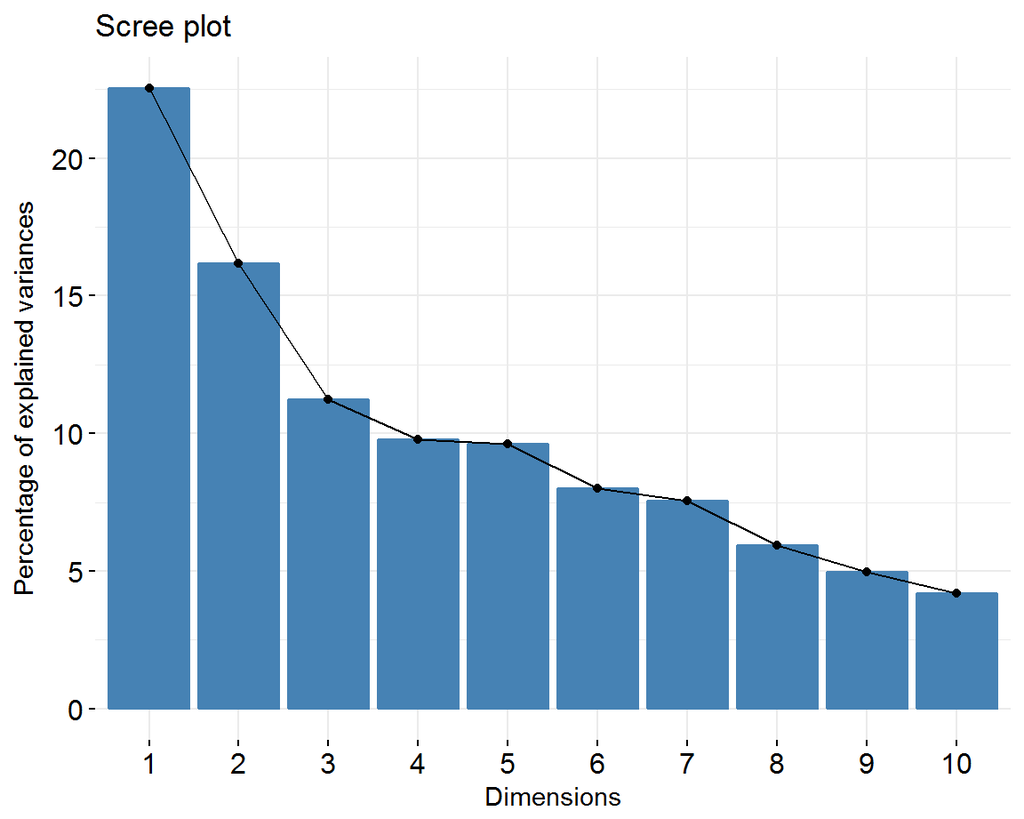

### qualité des representations des individus

```
        Dim.1      Dim.2       Dim.3      Dim.4        Dim.5      Dim.6
1 0.010705651 0.07590570 0.133149018 0.10539192 0.6267316296 0.01009339
2 0.167942697 0.33967945 0.006388805 0.08284111 0.0001441333 0.16516240
3 0.003147153 0.03683889 0.311670002 0.01983182 0.1029482317 0.01174068
4 0.193084994 0.07229227 0.204517886 0.02132255 0.0565246382 0.30946169
5 0.079276985 0.27005140 0.200302913 0.15164724 0.0339228611 0.08786420
6 0.415848237 0.21423592 0.029034123 0.08535011 0.0020432199 0.09621808
       Dim.7        Dim.8       Dim.9       Dim.10
1 0.01275520 0.0038230500 0.011929749 9.514692e-03
2 0.02704120 0.0351667307 0.054946147 1.206873e-01
3 0.05258611 0.0029640198 0.304287762 1.539853e-01
4 0.08498852 0.0111194058 0.009532107 3.715595e-02
5 0.01257068 0.0009304637 0.102355326 6.107793e-02
6 0.11445153 0.0305588251 0.012259894 6.457791e-08
```

### representation des individus et selon la consomation d’Alcool

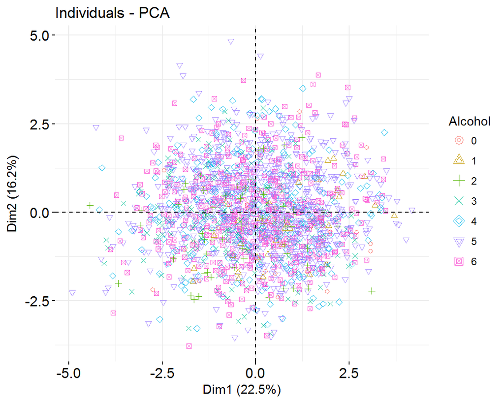

### representation des individus et selon la consomation d’Amphetamine

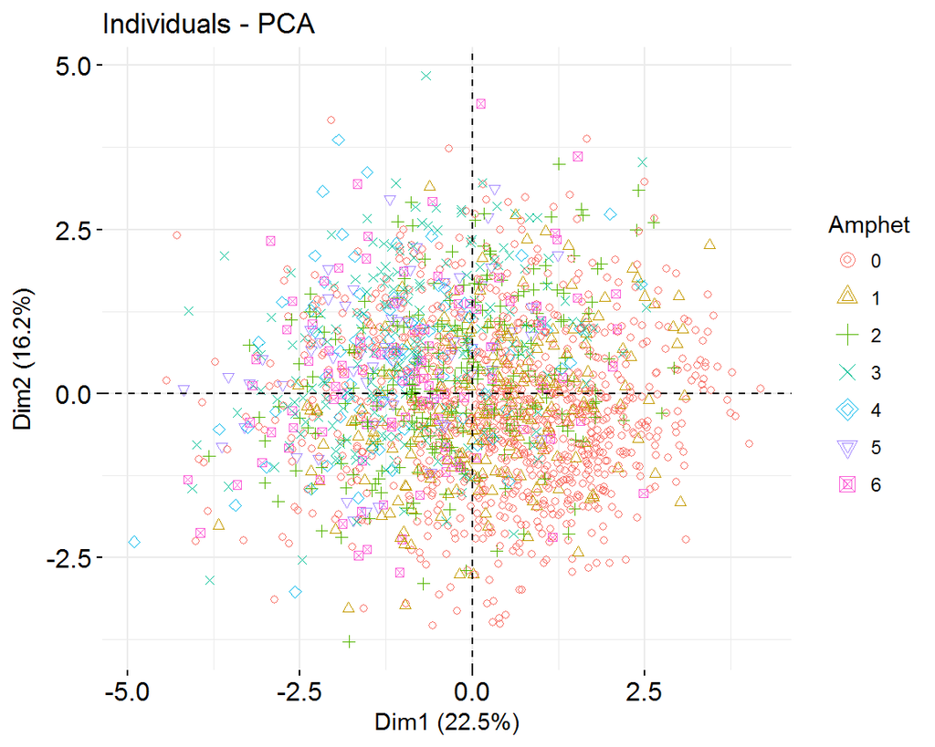

### representation des individus et selon la consomation de caffeine

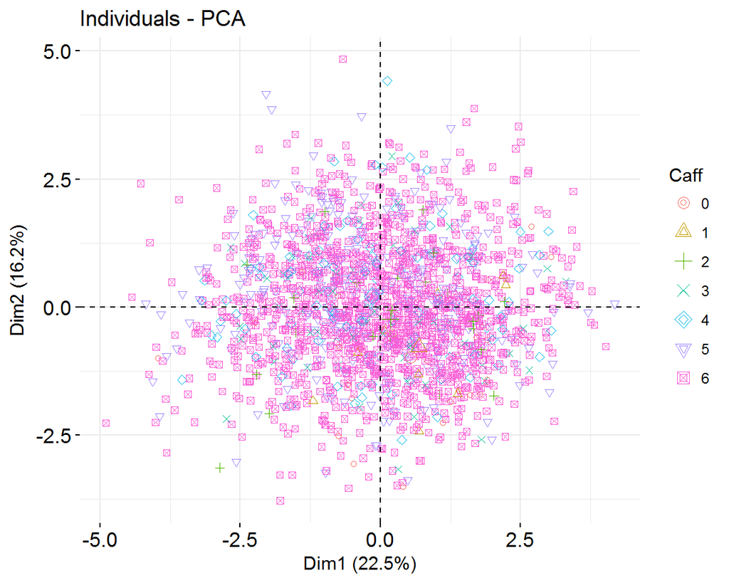

### representation des individus et selon la consomation d’heroine

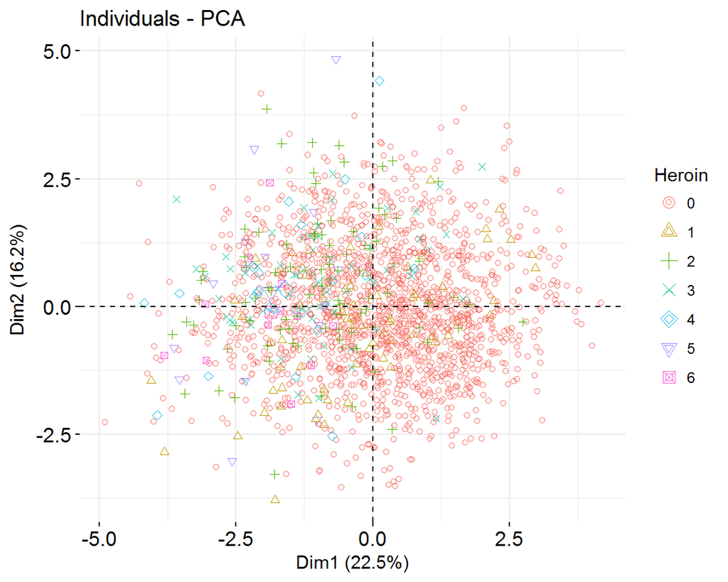

# Analyse en Composantes Principale des variables

Plusieur choses sont à retenir quant à cette representation: Premierement,amphetamine et heroine d’une part, et alcool et caffeine d’autres parts sont deux à deux corrrelés donc on pourrai considéré que ces stupefiants sont consomé dans les meme dégrés et aussi la consomation dalcool ou de caffeine n’influ pas sur la consomation d’heroine ou d’amphetamine. Deuxiemement, le premier groupe de stupefiants,en occurence heroine et amphetamine dependent de l’impulsivité,l’ethnie,le genre et l’age…le volume de consomation evolu avec l’impulsivité et inversement avec l’age,etan donné que lage minimal des individus est de 18ans, alors on peut dire que les grands consomateurs de ces stupefiants sont les plus jeunes gens avec un caractere fort impulsif. En outre le second groupe de stupefiant depend en quelque sorte aussi du genre et de l’age mais, les differentes personalitésetudiée ici n’ont aucune influence sur la consomation de ces drogues.

### qualité des representations des variables

```
               Dim.1        Dim.2       Dim.3       Dim.4        Dim.5
Age       0.16191153 0.1488954183 0.029636172 0.112722020 0.1372166610
Gender    0.14535019 0.0690665489 0.449754380 0.001699505 0.0153247812
Education 0.19137246 0.0002276207 0.171904334 0.344798043 0.0295348532
Ethnicity 0.01792511 0.0342747484 0.111428739 0.253274903 0.5684763050
Nscore    0.37618506 0.1387699146 0.219865464 0.006004739 0.0093008129
Escore    0.18188027 0.4932859350 0.002217856 0.003276085 0.0005989924
Oscore    0.02643898 0.4957860817 0.075877545 0.021590118 0.0166678537
Ascore    0.27863830 0.0059852650 0.052062261 0.160508391 0.1687497119
Cscore    0.57235845 0.0103494805 0.002852361 0.002731710 0.0116145730
Impulsive 0.30123492 0.2204155521 0.008521077 0.070377712 0.0032659731
                 Dim.6        Dim.7        Dim.8        Dim.9       Dim.10
Age       9.864614e-02 0.2711905407 0.0353781466 0.0021556324 2.247739e-03
Gender    1.826037e-01 0.0546227971 0.0096050988 0.0354480167 3.652496e-02
Education 1.458142e-01 0.0011547043 0.1137020404 0.0006285242 8.632030e-04
Ethnicity 4.952228e-03 0.0049245855 0.0045436390 0.0001164667 8.327416e-05
Nscore    9.303473e-04 0.0009083664 0.0532932104 0.0521997035 1.425424e-01
Escore    9.875368e-02 0.0312923187 0.0002110364 0.0141680018 1.743158e-01
Oscore    6.182405e-02 0.0904301409 0.1632455599 0.0303299004 1.780977e-02
Ascore    2.359343e-06 0.2434567543 0.0585836695 0.0284373901 3.575899e-03
Cscore    1.239732e-02 0.0517091400 0.1205359635 0.2088049970 6.646004e-03
Impulsive 1.934541e-01 0.0057933566 0.0359232431 0.1250589240 3.595517e-02
```

### Correlation entre les variables et les axes (composantes principales)

```
               Dim.1       Dim.2       Dim.3       Dim.4       Dim.5
Age        0.4023823 -0.38586969 -0.17215160  0.33574100  0.37042767
Gender     0.3812482 -0.26280515  0.67063729 -0.04122505 -0.12379330
Education  0.4374614  0.01508710  0.41461348  0.58719506  0.17185707
Ethnicity -0.1338847  0.18513441  0.33380944 -0.50326425  0.75397368
Nscore    -0.6133393 -0.37251834  0.46889814  0.07749025 -0.09644072
Escore     0.4264742  0.70234317 -0.04709412  0.05723709  0.02447432
Oscore    -0.1626007  0.70412079  0.27545879  0.14693576 -0.12910404
Ascore     0.5278620  0.07736449  0.22817156 -0.40063499 -0.41079157
Cscore     0.7565438  0.10173240 -0.05340750 -0.05226576  0.10777093
Impulsive -0.5488487  0.46948435  0.09230968  0.26528798  0.05714869
                 Dim.6       Dim.7       Dim.8       Dim.9       Dim.10
Age        0.314079829  0.52075958  0.18809079 -0.04642879  0.047410327
Gender     0.427321564 -0.23371521  0.09800561 -0.18827644 -0.191115041
Education -0.381856273 -0.03398094 -0.33719733  0.02507038  0.029380316
Ethnicity -0.070372068  0.07017539 -0.06740652 -0.01079198  0.009125468
Nscore    -0.030501595  0.03013912  0.23085322  0.22847254  0.377547858
Escore     0.314250981 -0.17689635 -0.01452709 -0.11902942  0.417511468
Oscore    -0.248644424  0.30071605  0.40403658 -0.17415482 -0.133453241
Ascore     0.001536015  0.49341337 -0.24204064  0.16863389  0.059798818
Cscore    -0.111343250 -0.22739644  0.34718290  0.45695185 -0.081523025
Impulsive  0.439834146  0.07611410 -0.18953428  0.35363671 -0.189618485
```

### cercle de correlation

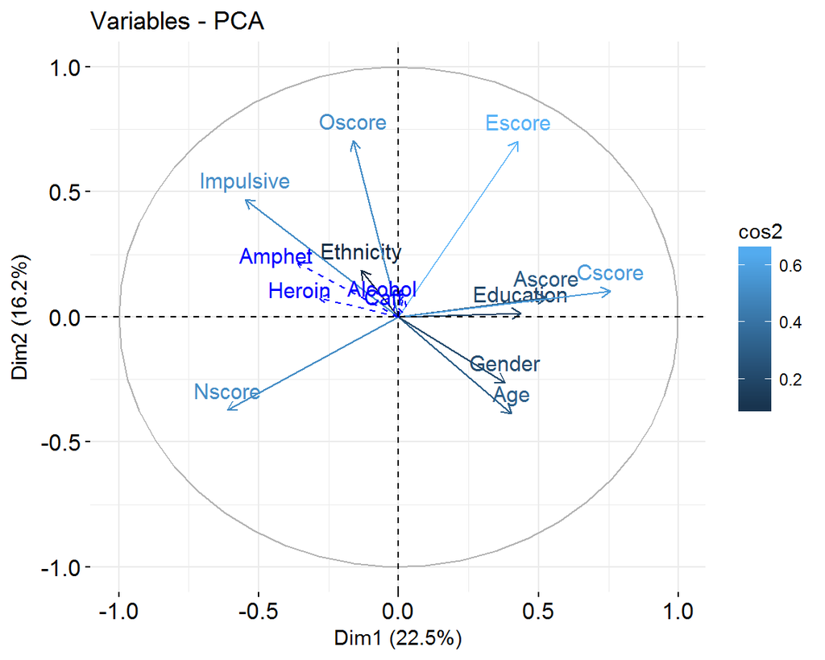